# Dummy data outline

Lars Murdock

2023-08-23

## Objective

We’re trying to create dummy data to use in the time series graphs for presentation work. The data is approved for extracted but we need to be careful about how and who we’re sharing it. So for the purposes of demonstrating the functionality of the SNOMED code dashboard, we don’t actually need to use real data.

It would be nice - and a good dev exercise - if the dummy data we create is plausible. We’re not trying to imitate a particular timeseries (eg a specific SNOMED code or cluster), but certain aspects would make it more realistic. For example a time series with negative numbers wouldn’t be plausible.

We can build this iteratively. Starting with the simplest time series, and not being too ambitious with the plausibility.

```r
# Create the time intervals (as an example i've just used years rather than mm-yyyy)
year_series <- c(1990:2021)

# Creating fake frequencies by sampling the normal distribution - and making there is a freq for each interval
basic_freq <- rnorm( length(year_series), 1000000, 50000)


fake_table <- cbind(year_series, basic_freq)
fake_table <- as.data.frame(fake_table)
colnames(fake_table) <- c("year", "freq")

head(fake_table)
```

```
##   year      freq
## 1 1990  995375.6
## 2 1991  951504.7
## 3 1992 1016267.5
## 4 1993  947660.1
## 5 1994 1010616.3
## 6 1995  958551.8
```

You can see this is pretty low fidelity because frequencies are not whole numbers.

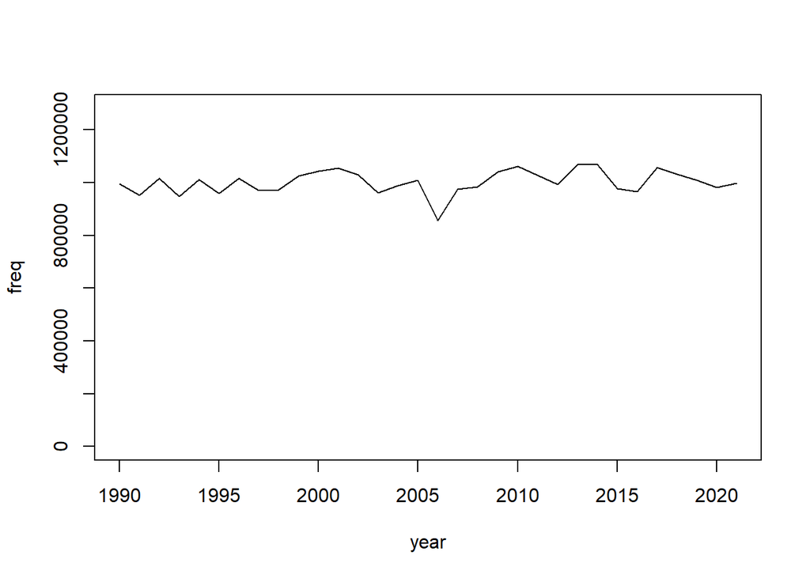

```r
plot(fake_table, type = "l", ylim = c(0, 1.2* max(fake_table$freq)) )
```

There are other characteristics in this graph that are less plausible, given most real time series do not start at 1990, and certainly not at full strength.

Instead they’ll begin in a more recent year, then increase and then plateau for the remaining time.

## Steps involved

We can map out the exercises we might want to attempt for this problem. As you can see they build iteratively.

1. generate a time series using rnorm (or similar if you find something better) plot and check by-eye if this looks like the kind of fluctuation you see in actual time series
2. adjust if not (might want to set.seed for this process) once you’re happy create a loop so you can generate multiple fake time series
3. some series represent large datasets, some smaller…. see if you can build this into your loop so they don’t all have the same mean
4. some series start long ago (like 1990) some only starter in the last 4 years. See if you can build this characteristic into your loop
5. so far you’ve created time series… but we haven’t tried to nest these (in the same way many snomed code time series make up one snomed cluster time series)… see if you can do this… then plot same as your coloured graphs
6. can we think of a way to mimic n vs n_distinct?
7. sense checks….. freq should never be below zero…. suppression…. every count should be round to the nearest 10

We’ve already achieved 1) in our demonstration purposed

### 2) Expanding to multiple time series

Context: Setting a seed

When using RNG or sampling, the randomness can be a problem. I might want to generate a number randomly… but should i happen to run the code again i may need/want to generate the same random number. By setting a seed we can make sure it starts with the same random number each time that seed is set. I’ve manually picked the seed ‘007’

```r
# without employing a set seed

print( rnorm( 5, 1000000, 50000))
```

```
## [1]  984259.6  983750.2 1003129.1 1055216.6  890992.3
```

```r
print( rnorm( 5, 1000000, 50000))
```

```
## [1] 1009705.2  882317.4 1077677.4  936789.7  954360.9
```

```r
# Now with a set seed

set.seed(007)
print( rnorm( 5, 1000000, 50000))
```

```
## [1] 1114362.4  940161.4  965285.4  979385.4  951466.3
```

```r
set.seed(007)
print( rnorm( 5, 1000000, 50000))
```

```
## [1] 1114362.4  940161.4  965285.4  979385.4  951466.3
```

```r
# It should be clear if you keep rerunning this chunk which change and which don't
```

Now lets try looping our first attempt so that we’re generating multiple time series

```r
# Establishing parameters
year_series <- c(1990:2021)
number_of_series <- 16
set.seed(007)

# Creating fake frequencies by sampling the normal distribution - and making there is a freq for each interval

listofseries <- list()

for(n in c(1:number_of_series)){
  # creating the series same as before
  basic_freq <- rnorm( length(year_series), 1000000, 50000)
  fake_table <- cbind(year_series, basic_freq)
  fake_table <- as.data.frame(fake_table)
  # label it and the cols
  fake_table[3] <- paste0("dummySNOMEDcode", n)
  colnames(fake_table) <- c("year", "freq", "codename")
  head(fake_table)
  listofseries[[n]] <- fake_table

# now saving we've created a time series for a code and labelled it, we can save this to our list and move onto the next loop

}

multipleCODEtable <- do.call("rbind", listofseries)
multipleCODEtable
```

```
##     year      freq          codename
## 1   1990 1114362.4  dummySNOMEDcode1
## 2   1991  940161.4  dummySNOMEDcode1
## 3   1992  965285.4  dummySNOMEDcode1
## 4   1993  979385.4  dummySNOMEDcode1
## 5   1994  951466.3  dummySNOMEDcode1
## 6   1995  952636.0  dummySNOMEDcode1
## 7   1996 1037407.0  dummySNOMEDcode1
## 8   1997  994152.2  dummySNOMEDcode1
## 9   1998 1007632.9  dummySNOMEDcode1
## 10  1999 1109498.9  dummySNOMEDcode1
## 11  2000 1017849.3  dummySNOMEDcode1
## 12  2001 1135837.6  dummySNOMEDcode1
## 13  2002 1114072.6  dummySNOMEDcode1
## 14  2003 1016201.0  dummySNOMEDcode1
```

[output cut: 498 more lines]

We can plot these lines to see what they look like.

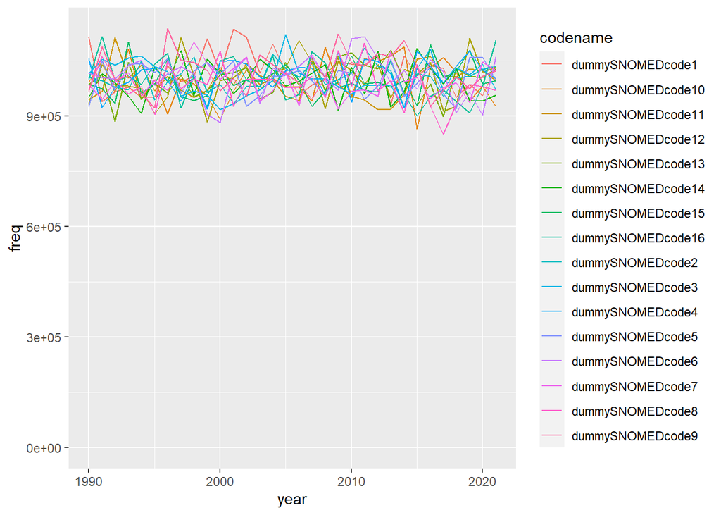

```r
library(ggplot2)
 ggplot(multipleCODEtable,  aes(x=year, y= freq, group=codename, color=codename)) +
    geom_line() + expand_limits(y=0)
```

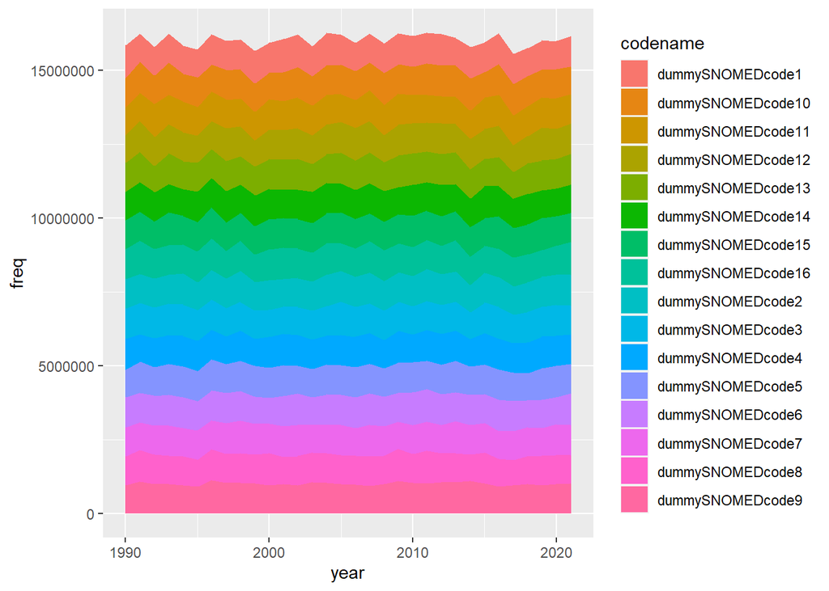

```r
library(ggplot2)

options(scipen = 100, digits = 22)

ggplot(multipleCODEtable, aes(x=year, y=freq, fill= codename)) +
    geom_area()
```

If we were pretending each of these codes represented a cluster (as with line graph), then it’d be strange that they were very similarly common.

If we were pretending each of these codes represented a code in a cluster (as with the stacked area chart), then again it’d be strange that they were all similarly common.

This is happening because each series can fluctuate, but they all have the same average.

### 3) Varying the size of the datasets

Some series represent large datasets, some smaller…. see if you can build this into your loop so they don’t all have the same mean

```r
# Establishing parameters
year_series <- c(1990:2021)
number_of_series <- 9
set.seed(007)
# Here we randomly generate the averages
random_averages <- rnorm( number_of_series, 10000, 5000)*100

# Creating fake frequencies by sampling the normal distribution - and making there is a freq for each interval

listofseries <- list()

for(n in c(1:number_of_series)){
  # creating the series same as before
  basic_freq <- rnorm( length(year_series), random_averages[n], 50000)
  fake_table <- cbind(year_series, basic_freq)
  fake_table <- as.data.frame(fake_table)
  # label it and the cols
  fake_table[3] <- paste0("dummySNOMEDconcept", n)
  colnames(fake_table) <- c("year", "cases", "codename")
  head(fake_table)
  listofseries[[n]] <- fake_table

# now saving we've created a time series for a code and labelled it, we can save this to our list and move onto the next loop

}

multipleCODEtable <- do.call("rbind", listofseries)
multipleCODEtable
```

```
##     year                    cases            codename
## 1   1990 2253122.4860367313958704 dummySNOMEDconcept1
## 2   1991 2161472.8921867134049535 dummySNOMEDconcept1
## 3   1992 2279461.1698267986066639 dummySNOMEDconcept1
## 4   1993 2257696.1769697400741279 dummySNOMEDconcept1
## 5   1994 2159824.6076771882362664 dummySNOMEDconcept1
## 6   1995 2238426.9340107589960098 dummySNOMEDconcept1
## 7   1996 2167007.6062363469973207 dummySNOMEDconcept1
## 8   1997 2098933.5445159901864827 dummySNOMEDconcept1
## 9   1998 2128257.1656934022903442 dummySNOMEDconcept1
## 10  1999 2143382.4595568836666644 dummySNOMEDconcept1
## 11  2000 2193031.7881452594883740 dummySNOMEDconcept1
## 12  2001 2185611.0986514659598470 dummySNOMEDconcept1
## 13  2002 2178890.6722155371680856 dummySNOMEDconcept1
## 14  2003 2208921.8167108464986086 dummySNOMEDconcept1
```

[output cut: 274 more lines]

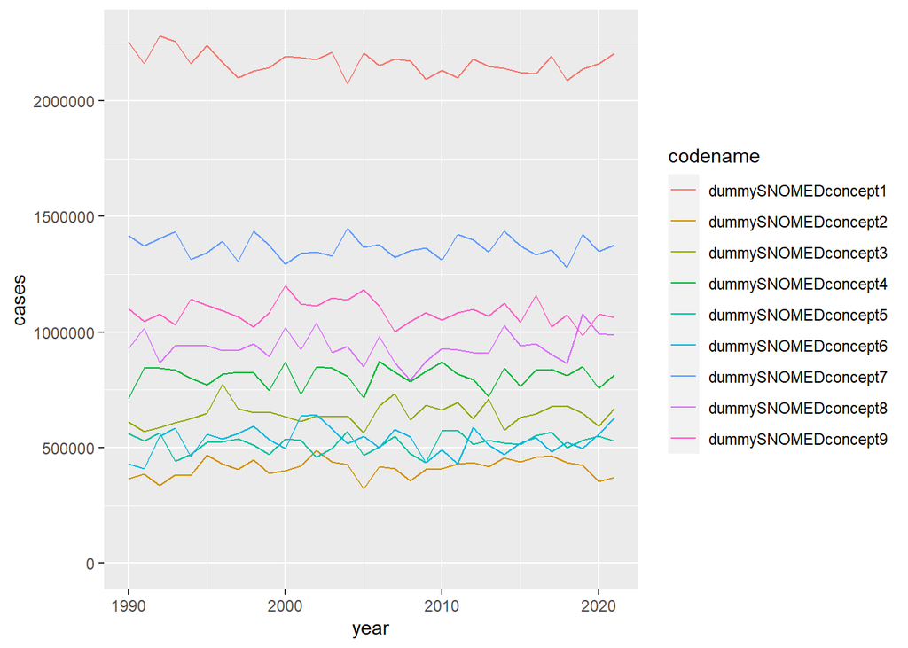

```r
library(ggplot2)

 ggplot(multipleCODEtable,  aes(x=year, y= cases, group=codename, color=codename)) +
    geom_line() + expand_limits(y=0)
```

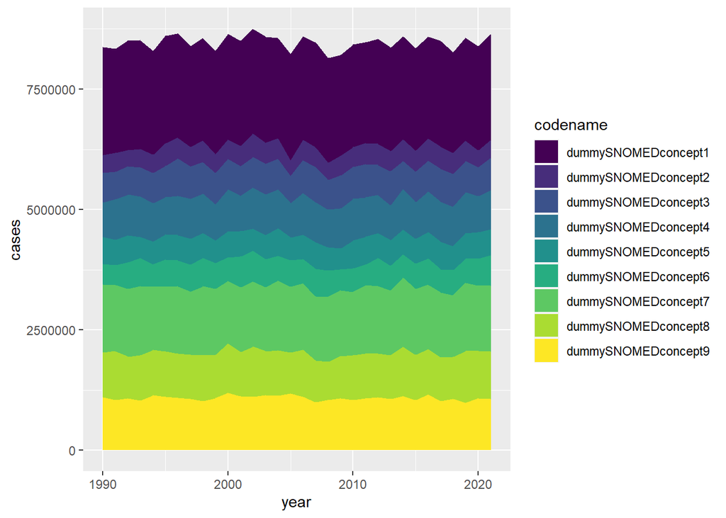

```r
library(ggplot2)
library(viridis)
options(scipen = 100, digits = 22)

ggplot(multipleCODEtable, aes(x=year, y=cases, fill= codename)) +
    geom_area() +
  scale_fill_viridis(discrete = TRUE)
```

This looks much more like the variety you see between clusters or within a cluster.

###4) Introducing different starting points

Some series start long ago (like 1990) whereas some only started in the last 4 years. We want to see if we can build this characteristic into our loop

It’s easier to demonstrate this by going back to our simpler chunk from step 2. We’re going to sample from a set of values

```r
start_years <- c(1990:2018)

startyear <- sample( start_years, 1, replace = TRUE)
sum(start_years < startyear)
```

```
## [1] 14
```

If you keep running the above it’ll keep picking at random a year for the data to start from

So we incorporate this into our loop now

```r
# Establishing parameters
year_series <- c(1990:2021)
number_of_series <- 5
set.seed(007)

# Establishing all the possible years the data could start in
start_years <- c(1990:2018)
selected_start_years <- sample( start_years, 5, replace = TRUE)


# Establishing the possible values before this point. They're negligible but sometimes rounded to 10 due to suppression
low_values <- c(0, 10)


# Creating fake frequencies by sampling the normal distribution - and making there is a freq for each interval

listofseries <- list()

for(n in c(1:number_of_series)){
  # creating the series same as before
  basic_freq <- rnorm( length(year_series), 1000000, 50000)
  fake_table <- cbind(year_series, basic_freq)
  fake_table <- as.data.frame(fake_table)

  # label it and the cols
  fake_table[3] <- paste0("dummySNOMEDcode", n)
  colnames(fake_table) <- c("year", "freq", "codename")
  head(fake_table)

  # Now introducing a start year
  start_year <- selected_start_years[n]
  # Establishing how many years preceed this
  yearsbefore <- sum(start_years < start_year)
  # Replacing the earlier frequencies with a negligible value
  fake_table$freq[ 1:yearsbefore] <- sample( low_values, yearsbefore, replace = TRUE)


  listofseries[[n]] <- fake_table

# now saving we've created a time series for a code and labelled it, we can save this to our list and move onto the next loop

}

multipleCODEtable <- do.call("rbind", listofseries)
multipleCODEtable
```

```
##     year                     freq         codename
## 1   1990      10.0000000000000000 dummySNOMEDcode1
## 2   1991      10.0000000000000000 dummySNOMEDcode1
## 3   1992       0.0000000000000000 dummySNOMEDcode1
## 4   1993      10.0000000000000000 dummySNOMEDcode1
## 5   1994      10.0000000000000000 dummySNOMEDcode1
## 6   1995       0.0000000000000000 dummySNOMEDcode1
## 7   1996       0.0000000000000000 dummySNOMEDcode1
## 8   1997      10.0000000000000000 dummySNOMEDcode1
## 9   1998      10.0000000000000000 dummySNOMEDcode1
## 10  1999 1114072.5962994778528810 dummySNOMEDcode1
## 11  2000 1016201.0270069257821888 dummySNOMEDcode1
## 12  2001 1094803.3533404965419322 dummySNOMEDcode1
## 13  2002 1023384.0255660848924890 dummySNOMEDcode1
## 14  2003  955309.9638457278488204 dummySNOMEDcode1
```

[output cut: 146 more lines]

We can plot these lines to see what they look like.

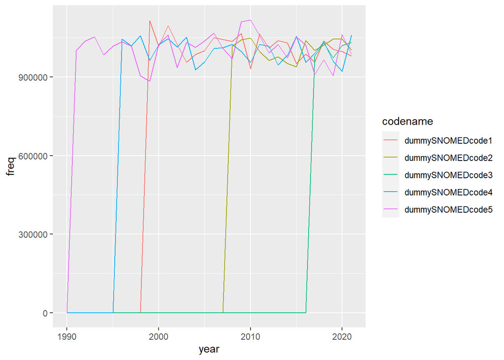

```r
library(ggplot2)

 ggplot(multipleCODEtable,  aes(x=year, y= freq, group=codename, color=codename)) +
    geom_line() + expand_limits(y=0)
```

### 6) generating ‘n’ , ‘n_id’ and ‘n_id_distinct’

The three measures given for concepts/clusters are ‘n’ , ‘n_id’ and ‘n_id_distinct’.

- n means how many applicable records there were.
- n_id means how many applicable records there were that has an individual tied to it.
- n_id_distinct means how many different individuals have at least one record.

Seems like all the records had an id attached, when looking at the actual data, so we’ll mimic that.

n_id_distinct must be lower than n, and is fairly proportional to the overall volume. So we’ll randomly determine what proportion it is.

```r
# Establishing parameters
year_series <- c(1990:2021)
number_of_series <- 5
set.seed(007)
# Here we randomly generate the averages
random_averages <- rnorm( number_of_series, 10000, 5000)*100

# Some proportions to decide how the relationship between records and people
random_props <- rnorm( length(year_series), 0.6 , 0.075)

# Creating fake frequencies by sampling the normal distribution - and making there is a freq for each interval

listofseries <- list()

for(i in c(1:number_of_series)){
  # creating the series same as before
  n <- rnorm( length(year_series), random_averages[i], 50000)
  n_id <- n
  n_distinct_id <- n * random_props
  fake_table <- cbind(year_series, n)
  fake_table <- as.data.frame(fake_table)
  fake_table$n_id <- n_id
  fake_table$n_distinct_id <- n_distinct_id
  # label it and the cols
  fake_table[5] <- paste0("dummyConceptcode", i)
  colnames(fake_table)[1] <- c("year")
  colnames(fake_table)[5] <- c("concept")
  head(fake_table)
  listofseries[[i]] <- fake_table

# now saving we've created a time series for a code and labelled it, we can save this to our list and move onto the next loop

}

multipleCODEtable <- do.call("rbind", listofseries)
head(multipleCODEtable)
```

```
##   year                       n                    n_id           n_distinct_id
## 1 1990 2088367.077729599084705 2088367.077729599084705 1104650.127812168560922
## 2 1991 2136509.189131532795727 2136509.189131532795727 1401786.006625036941841
## 3 1992 2159373.325914657674730 2159373.325914657674730 1276682.745915766805410
## 4 1993 2204551.107395629398525 2204551.107395629398525 1347971.279867844190449
## 5 1994 2108657.726735986303538 2108657.726735986303538 1611538.205346797825769
## 6 1995 2129351.943093826062977 2129351.943093826062977 1334622.365096959052607
##             concept
## 1 dummyConceptcode1
## 2 dummyConceptcode1
## 3 dummyConceptcode1
## 4 dummyConceptcode1
## 5 dummyConceptcode1
## 6 dummyConceptcode1
```

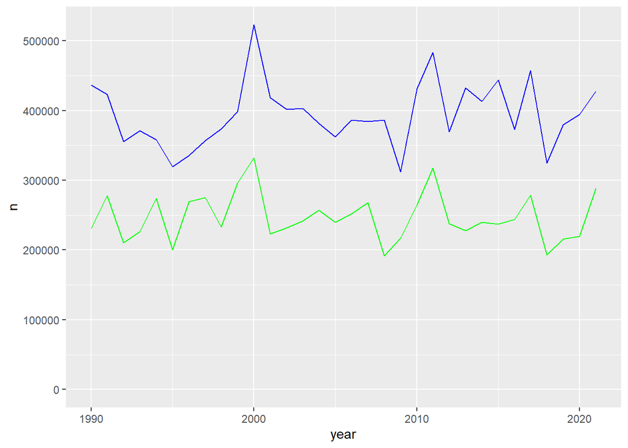

```r
library(ggplot2)
library(dplyr)
specificCode <- multipleCODEtable %>% filter( concept == "dummyConceptcode2"  )

ggplot(specificCode,  aes(x = year)) +
  geom_line(aes(y = n), color = "black") +
  geom_line(aes(y = n_distinct_id), color = "green") +
  geom_line(aes(y = n_id), color = "blue") +
  expand_limits(y = 0)
```